# R online Training Introduction

Last modified: 03 Mar 2025

## History of R

## Notable uses

- [Facebook](http://blog.revolutionanalytics.com/2010/12/analysis-of-facebook-status-updates.html),
- [google](http://blog.revolutionanalytics.com/2009/05/google-using-r-to-analyze-effectiveness-of-tv-ads.html),
- [Microsoft](http://blog.revolutionanalytics.com/2014/05/microsoft-uses-r-for-xbox-matchmaking.html) (who recently [invested](http://blogs.microsoft.com/blog/2015/01/23/microsoft-acquire-revolution-analytics-help-customers-find-big-data-value-advanced-statistical-analysis/) in a commerical provider of R)
- The [New York Times](http://blog.revolutionanalytics.com/2011/03/how-the-new-york-times-uses-r-for-data-visualization.html).
- [Buzzfeed](http://blog.revolutionanalytics.com/2015/12/buzzfeed-uses-r-for-data-journalism.html) use R for some of their serious articles and have made the code [publically available](https://buzzfeednews.github.io/2016-04-federal-surveillance-planes/analysis.html)
- The [New Zealand Tourist Board](https://mbienz.shinyapps.io/tourism_dashboard_prod/) have R running in the background of their website
- The BBC makes code available for some of their stories (e.g. [gender bias in music festivals](https://github.com/BBC-Data-Unit/music-festivals))
- [Airbnb](https://medium.com/airbnb-engineering/using-r-packages-and-education-to-scale-data-science-at-airbnb-906faa58e12d)

## A relevant example

[figure not shown]

## Topics covered

- The Rstudio environment
- Reproducible Reporting
- Importing data from a spreadsheet
- Filtering Data
- Plotting and customisation of plots
- Calculating numerical summaries
- Joining data from multiple spreadsheets

## Packages covered

- We will cover a very small set of packages - the **tidyverse**

[figure not shown]

*Image Credit:* [*Aberdeen Study Group*](https://aberdeenstudygroup.github.io/studyGroup/lessons/SG-T2-JointWorkshop/PopulationChangeSpeciesOccurrence/)

## Can’t we just do these things in Excel?

- Spreadsheets are a common entry point for many types of analysis and Excel is used widely but
  - can be unwieldy and difficult to deal with large amounts of data
- error prone (e.g. gene symbols turning into dates)
- tedious and time consuming to repeatedly process multiple files
- how can you, or someone else, repeat what you did several months or years down the line?

## Facilitating reproducible research

[video not shown]

## Course Data

[figure not shown]

- We will use data from the gapminder project

## Example plots

- By the end of the course we will be creating plots like this in a few lines of code

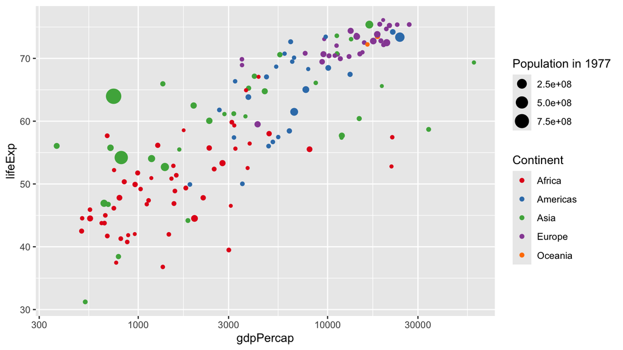

## Example plots

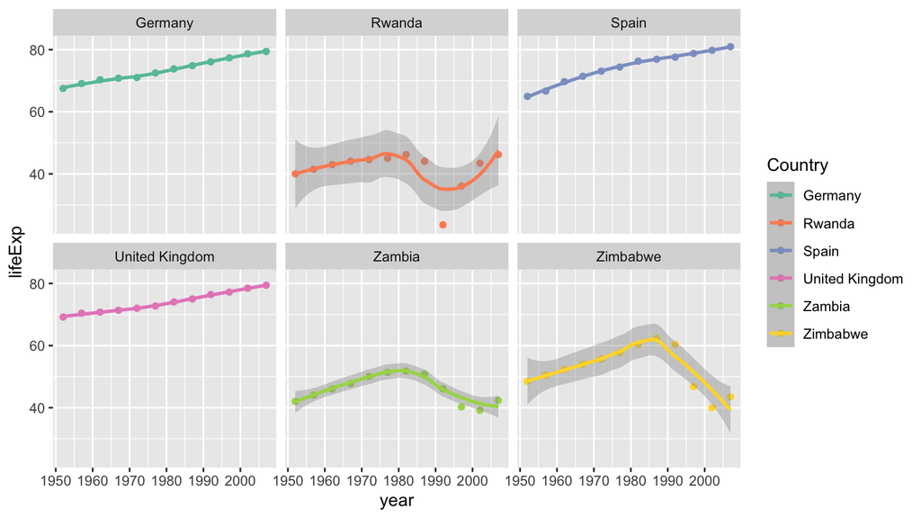

## Course Outline

- Session 1:- RStudio and R basis, Reading data into R
- Session 2:- Data manipulation and plotting
- Session 3:- Further plotting, Summarising, joining tables and open-ended practice

## Resources

- [Tidyverse website](https://www.tidyverse.org/)
- [RStudio cheatsheets](https://www.rstudio.com/resources/cheatsheets/)
- [R graph gallery](https://www.r-graph-gallery.com/0)
- [Sheffield R meetup](https://www.meetup.com/SheffieldR-Sheffield-R-Users-Group/)
- [Stack Overflow](https://stackoverflow.com/questions/tagged/r)
- [R bloggers](https://www.r-bloggers.com/)
- google!

## Thanks

- Materials at https://sbc.shef.ac.uk/training/r-online/
- Find this useful? Tell your colleagues and mention us on twitter
  - `@SheffBioinfCore`